[figure not shown]

Imagine que você tem um conjunto de dados que contém as notas de alunos de três turmas diferentes, registradas em diferentes formatos (algumas em números de 0 a 10, outras em letras como A, B, C).

Seu objetivo é analisar o desempenho dos alunos de todas as turmas juntos. Quais passos você seguiria para transformar e combinar esses dados, permitindo uma análise precisa e padronizada? Descreva as etapas que você realizaria e as ferramentas que utilizaria, com base nos conceitos aprendidos.

# Imports

```python
from IPython.core.display import HTML

import pandas as pd
import numpy  as np

# Geração de números aleatórios:
import random

# Gráficos:
import matplotlib.pyplot as plt
import seaborn           as sns
```

## Page_Formation

```python
HTML('''
<style>
    /* Aplicar fonte monoespaçada a todo o notebook */
    body, div.text_cell_render, div.code_cell pre, h1, h2, h3, h4, p {
        font-family: "Courier New", Consolas, Monaco, monospace; /* Fonte monoespaçada */
    }

    /* Estilo para h1 */
    h3{
        color: #0a1f44;            /* Cor do texto (azul marinho) */
        background-color: #dcdde1; /* Fundo azul escuro (cinza mais escuro) */
        border-radius: 8px;        /* Bordas arredondadas */
        padding: 10px;
    }

    /* Estilo para h2 */
    h1{
        color: #dcdde1;            /* Cor do texto (cinza claro) */
        background-color: #0a1f44; /* Fundo azul escuro (azul marinho) */
        border-radius: 8px;        /* Bordas arredondadas */
        padding: 10px;
    }

    /* Estilo para h3 */
    h2{
        color:#dcdde1;            /* Cor do texto (azul mais claro) */
        background-color: #40739e; /* Fundo azul escuro (cinza mais escuro) */
        border-radius: 8px;        /* Bordas arredondadas */
        padding: 10px;
    }

    /* Estilo para h4 e h5 */
    h4, h5 {
        background-color:#40739e;  /* Fundo azul marinho */
        color: white;               /* Texto branco */
        border-radius: 8px;         /* Bordas arredondadas */
        padding: 10px;
    }
</style>
''')
```

# Passo 0:

Criando o dataframe:

```python
'''
data = {
    "Turma1": [],
    "Turma2": [],
    "Turma3": []
}
'''
# Declarando as listas
Turma1 = []
Turma2 = []
Turma3 = []

# Definindo uma semente de aleatoriedade fixa, para que as análises nos
# próximos passos tenham
random.seed(42)

# Declarnado a quantidade de valores em cada lista:
n = 50

# Relizando um laço for para o preenchimento das listas com os valores:
for i in range(n):
    Turma1.append(random.choice(list(range(11)) + list('ABCDE')))
    Turma2.append(random.choice(list(range(11)) + list('ABCDE')))
    Turma3.append(random.choice(list(range(11)) + list('ABCDE')))


print(f'Notas Turma 1:\n\n{Turma1}\n')

print(f'Notas Turma 2:\n\n{Turma2}\n')

print(f'Notas Turma 3:\n\n{Turma3}')
```

```
Notas Turma 1:

[3, 7, 3, 1, 6, 6, 'D', 5, 8, 10, 'B', 'A', 'D', 2, 6, 7, 7, 8, 5, 6, 5, 'D', 7, 7, 'B', 6, 'E', 4, 7, 'B', 4, 1, 5, 'B', 8, 8, 9, 'D', 5, 6, 5, 'E', 'A', 1, 2, 4, 5, 6, 'B', 'D']

Notas Turma 2:

[0, 7, 2, 0, 7, 'C', 8, 'C', 4, 3, 3, 8, 3, 9, 2, 9, 3, 'D', 'A', 8, 7, 'B', 10, 1, 8, 10, 'B', 8, 8, 'A', 'E', 3, 'C', 'B', 0, 10, 'C', 0, 3, 4, 0, 0, 9, 7, 'E', 4, 8, 6, 'A', 3]

Notas Turma 3:

[8, 4, 'C', 2, 0, 7, 0, 10, 6, 2, 'A', 1, 'B', 'A', 1, 2, 'B', 'A', 'A', 2, 5, 8, 1, 10, 2, 6, 'D', 4, 'C', 7, 2, 4, 2, 'D', 3, 3, 5, 8, 9, 'A', 10, 3, 7, 2, 2, 'E', 'C', 9, 'D', 7]
```

# Passo 1:

Identificação e Transformando os Dados:

- Primeiro, identifique as diferentes formas de registro das notas (números e letras). Utilize a técnica de substituição para transformar as notas em letras (A, B, C) para uma escala numérica correspondente (por exemplo, A = 10, B = 8, C = 6). Essa transformação é essencial para padronizar os dados, garantindo que todas as notas estejam na mesma escala numérica e facilitando a análise conjunta.

```python
print(f'Identificandoo os valores únicos na Turma1: \n{set(Turma1)}\n')

print(f'Identificandoo os valores únicos na Turma1: \n{set(Turma2)}\n')

print(f'Identificandoo os valores únicos na Turma1: \n{set(Turma3)}')
```

```
Identificandoo os valores únicos na Turma1:
{1, 2, 3, 4, 5, 6, 7, 8, 'D', 10, 'B', 'A', 9, 'E'}

Identificandoo os valores únicos na Turma1:
{0, 1, 2, 3, 4, 'A', 7, 8, 9, 'D', 'B', 10, 6, 'E', 'C'}

Identificandoo os valores únicos na Turma1:
{0, 1, 2, 3, 4, 5, 6, 7, 8, 'A', 10, 'B', 'D', 9, 'E', 'C'}
```

Para a transformação das letras identificadas na lista, será utilizado o seguinte gabarito: A = 10, B = 8, C = 6, D = 4, E = 2.

```python
# Apresentação das turmas antes das substituições:;
print(f'Notas Turma 1:\n\n{Turma1}\n')

print(f'Notas Turma 2:\n\n{Turma2}\n')

print(f'Notas Turma 3:\n\n{Turma3}')
```

```
Notas Turma 1:

[3, 7, 3, 1, 6, 6, 'D', 5, 8, 10, 'B', 'A', 'D', 2, 6, 7, 7, 8, 5, 6, 5, 'D', 7, 7, 'B', 6, 'E', 4, 7, 'B', 4, 1, 5, 'B', 8, 8, 9, 'D', 5, 6, 5, 'E', 'A', 1, 2, 4, 5, 6, 'B', 'D']

Notas Turma 2:

[0, 7, 2, 0, 7, 'C', 8, 'C', 4, 3, 3, 8, 3, 9, 2, 9, 3, 'D', 'A', 8, 7, 'B', 10, 1, 8, 10, 'B', 8, 8, 'A', 'E', 3, 'C', 'B', 0, 10, 'C', 0, 3, 4, 0, 0, 9, 7, 'E', 4, 8, 6, 'A', 3]

Notas Turma 3:

[8, 4, 'C', 2, 0, 7, 0, 10, 6, 2, 'A', 1, 'B', 'A', 1, 2, 'B', 'A', 'A', 2, 5, 8, 1, 10, 2, 6, 'D', 4, 'C', 7, 2, 4, 2, 'D', 3, 3, 5, 8, 9, 'A', 10, 3, 7, 2, 2, 'E', 'C', 9, 'D', 7]
```

```python
# Dicionário de substituições
substituicoes = {
    'A': 10,
    'B': 8,
    'C': 6,
    'D': 4,
    'E': 2
}

# Aplicando as substituições nas Turmas
Turma1_substituida = [substituicoes.get(item, item) for item in Turma1]
Turma2_substituida = [substituicoes.get(item, item) for item in Turma2]
Turma3_substituida = [substituicoes.get(item, item) for item in Turma3]

# Apresentação dos Resultados
print(f'Notas Turma 1:\n\n{Turma1_substituida}\n')
print(f'Notas Turma 2:\n\n{Turma2_substituida}\n')
print(f'Notas Turma 3:\n\n{Turma3_substituida}')
```

```
Notas Turma 1:

[3, 7, 3, 1, 6, 6, 4, 5, 8, 10, 8, 10, 4, 2, 6, 7, 7, 8, 5, 6, 5, 4, 7, 7, 8, 6, 2, 4, 7, 8, 4, 1, 5, 8, 8, 8, 9, 4, 5, 6, 5, 2, 10, 1, 2, 4, 5, 6, 8, 4]

Notas Turma 2:

[0, 7, 2, 0, 7, 6, 8, 6, 4, 3, 3, 8, 3, 9, 2, 9, 3, 4, 10, 8, 7, 8, 10, 1, 8, 10, 8, 8, 8, 10, 2, 3, 6, 8, 0, 10, 6, 0, 3, 4, 0, 0, 9, 7, 2, 4, 8, 6, 10, 3]

Notas Turma 3:

[8, 4, 6, 2, 0, 7, 0, 10, 6, 2, 10, 1, 8, 10, 1, 2, 8, 10, 10, 2, 5, 8, 1, 10, 2, 6, 4, 4, 6, 7, 2, 4, 2, 4, 3, 3, 5, 8, 9, 10, 10, 3, 7, 2, 2, 2, 6, 9, 4, 7]
```

# Passo 2:

- Após a substituição, verifique se todas as notas estão dentro de uma escala uniforme. Se necessário, aplique uma técnica de normalização para ajustar as notas a uma escala comum, como de 0 a 10. Isso é importante para assegurar que as notas sejam comparáveis entre as turmas, evitando distorções na análise.

```python
# Analisando os valores máximos e mínimos presentes nas Turmas:
print(f'Valor máximo presente na Turma 1: {max(Turma1_substituida)}\n'
      f'Valor mínimo presente na Turma 1: {min(Turma1_substituida)}\n\n'
      f'Valor mínimo presente na Turma 2: {max(Turma2_substituida)}\n'
      f'Valor mínimo presente na Turma 2: {min(Turma2_substituida)}\n\n'
      f'Valor mínimo presente na Turma 3: {max(Turma3_substituida)}\n'
      f'Valor mínimo presente na Turma 3: {min(Turma3_substituida)}\n')

max(Turma1_substituida)
```

```
Valor máximo presente na Turma 1: 10
Valor mínimo presente na Turma 1: 1

Valor mínimo presente na Turma 2: 10
Valor mínimo presente na Turma 2: 0

Valor mínimo presente na Turma 3: 10
Valor mínimo presente na Turma 3: 0
```

```
10
```

Verificamos, a partir da saída apresentada acima, que os três conjuntos possuem a mesma escala de variação de valores. Portanto, não é necessário aplicar nenhuma técnica de normalização ou transformação em nenhum dos conjuntos, visto que o estudo de comparação pode ser realizado com os dados na forma em que estão apresentados.

# Passo 3:

- Utilize a função concat() do pandas para combinar os registros de notas das três turmas em um único DataFrame. Essa etapa permite que você una todos os dados em um único conjunto, possibilitando uma análise conjunta das turmas.

```python
# Transformando as listas em Dataframe:
df_Turma1 = pd.DataFrame(Turma1_substituida)
df_Turma2 = pd.DataFrame(Turma2_substituida)
df_Turma3 = pd.DataFrame(Turma3_substituida)
```

```python
# Juntando os três Datasets:
df_Turmas = pd.concat([df_Turma1, df_Turma2, df_Turma3], axis=1)
df_Turmas.columns = ['Turma1', 'Turma2', 'Turma3']
```

```python
# Apresentação dos Dataset completo:
df_Turmas
```

|  | Turma1 | Turma2 | Turma3 |
| --- | --- | --- | --- |
| 0 | 3 | 0 | 8 |
| 1 | 7 | 7 | 4 |
| 2 | 3 | 2 | 6 |
| 3 | 1 | 0 | 2 |
| 4 | 6 | 7 | 0 |
| 5 | 6 | 6 | 7 |
| 6 | 4 | 8 | 0 |
| 7 | 5 | 6 | 10 |
| 8 | 8 | 4 | 6 |
| 9 | 10 | 3 | 2 |
| 10 | 8 | 3 | 10 |
| 11 | 10 | 8 | 1 |
| 12 | 4 | 3 | 8 |
| 13 | 2 | 9 | 10 |
| 14 | 6 | 2 | 1 |
| 15 | 7 | 9 | 2 |
| 16 | 7 | 3 | 8 |
| 17 | 8 | 4 | 10 |
| 18 | 5 | 10 | 10 |
| 19 | 6 | 8 | 2 |
| 20 | 5 | 7 | 5 |
| 21 | 4 | 8 | 8 |
| 22 | 7 | 10 | 1 |
| 23 | 7 | 1 | 10 |
| 24 | 8 | 8 | 2 |
| 25 | 6 | 10 | 6 |
| 26 | 2 | 8 | 4 |
| 27 | 4 | 8 | 4 |
| 28 | 7 | 8 | 6 |
| 29 | 8 | 10 | 7 |
| 30 | 4 | 2 | 2 |
| 31 | 1 | 3 | 4 |
| 32 | 5 | 6 | 2 |
| 33 | 8 | 8 | 4 |
| 34 | 8 | 0 | 3 |
| 35 | 8 | 10 | 3 |
| 36 | 9 | 6 | 5 |
| 37 | 4 | 0 | 8 |
| 38 | 5 | 3 | 9 |
| 39 | 6 | 4 | 10 |
| 40 | 5 | 0 | 10 |
| 41 | 2 | 0 | 3 |
| 42 | 10 | 9 | 7 |
| 43 | 1 | 7 | 2 |
| 44 | 2 | 2 | 2 |
| 45 | 4 | 4 | 2 |
| 46 | 5 | 8 | 6 |
| 47 | 6 | 6 | 9 |
| 48 | 8 | 10 | 4 |
| 49 | 4 | 3 | 7 |

# Passo 4:

- Com os dados padronizados e combinados, você pode proceder com a análise. Crie gráficos usando matplotlib ou seaborn para visualizar o desempenho geral das turmas, como um gráfico de distribuição para observar a dispersão das notas ou um gráfico de barras comparando a média de cada turma.

```python
# Análise estatística resumida:
df_Turmas.describe()
```

|  | Turma1 | Turma2 | Turma3 |
| --- | --- | --- | --- |
| count | 50.000000 | 50.000000 | 50.000000 |
| mean | 5.580000 | 5.420000 | 5.240000 |
| std | 2.416694 | 3.301762 | 3.197959 |
| min | 1.000000 | 0.000000 | 0.000000 |
| 25% | 4.000000 | 3.000000 | 2.000000 |
| 50% | 6.000000 | 6.000000 | 5.000000 |
| 75% | 7.750000 | 8.000000 | 8.000000 |
| max | 10.000000 | 10.000000 | 10.000000 |

De forma, inicial e resumida, podemos identificar que a Turma1 apresentou uma média um pouco maior em relação as outras duas turmas, isso porque a concentração de valores abaixo do primeiro quartil é um valor um pouco maior do que das demais turmas. Também é possível identificar uma baixa variação nas notas da Turma1 em relação as demais.

- Com essa baixa variação talvez a turma1 e as demais teve um alto percentual de erro em questões especificas, seria então interessante analisar tais questões e reforçar o entendimento dessas com as turmas. Desconsiderando, claro dentro desse cenário a possibilidade de troca de informação durante a realização da avaliação.

## Distribuição das notas por Turma

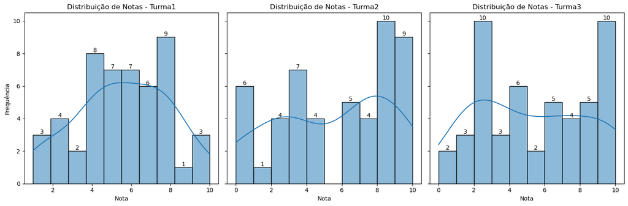

```python
# Configuração dos subplots:
fig, axes = plt.subplots(1, 3, figsize=(15, 5), sharey=True)

# Iteração para cada turma:
for i, turma in enumerate(["Turma1", "Turma2", "Turma3"]):
    ax = axes[i]
    plot = sns.histplot(data=df_Turmas, x=turma, kde=True, bins=10, ax=ax)
    ax.set_title(f"Distribuição de Notas - {turma}")
    ax.set_xlabel("Nota")
    ax.set_ylabel("Frequência")

    # Adicionando os valores nas barras
    for p in plot.patches:
        height = int(p.get_height())
        if height > 0:
            ax.text(p.get_x() + p.get_width() / 2., height, str(height), ha='center', va='bottom')

plt.tight_layout()
plt.show()
```

Temos algumas informações interessantes apresentadas no histograma das notas de cada turma. Primeiramente, observa-se uma concentração maior de notas altas na Turma 2, o que é interessante, considerando que a turma com a maior média geral é a Turma 1. Na Turma 1, por apresentar uma maior concentração de notas entre 4 e 8, percebe-se um nivelamento em um nível intermediário. Já na Turma 2, há muitos alunos com rendimentos muito bons, enquanto, na Turma 3, concentra-se um número significativo de alunos com rendimento inferior a 4.

## Plotado vários gráficos para análise:

- boxplot
- barras
- barras agrupadas
- violino

Pelo boxplot, podemos identificar novamente a concentração dos dados na Turma 1. No Gráfico 2, observa-se uma média maior na Turma 1. Já no Gráfico 3, é destacado o que está causando a diminuição da média geral na Turma 3, ou seja, há uma concentração maior de valores em notas baixas. No Gráfico 4, também é possível identificar as concentrações de dados em cada turma e os respectivos intervalos.

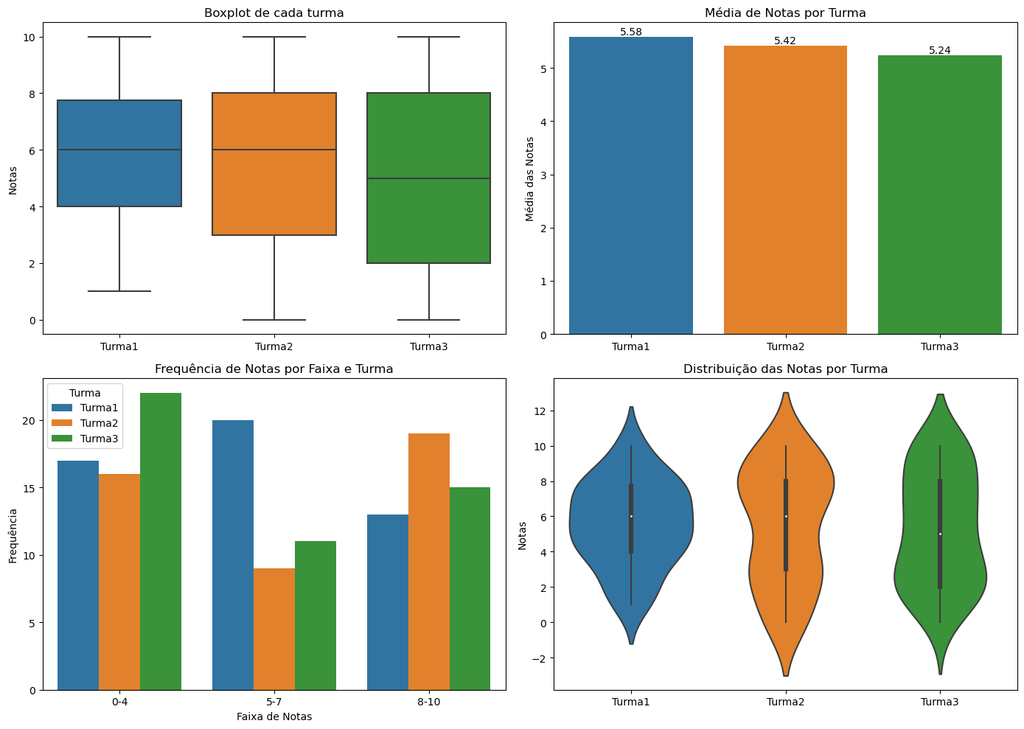

```python
# Configuração dos subplots:
fig, axes  = plt.subplots(2, 2, figsize=(14, 10))

# Boxplot:
sns.boxplot(data=df_Turmas, ax=axes[0, 0])
axes[0, 0].set_title('Boxplot de cada turma')
axes[0, 0].set_ylabel('Notas')

# Barplot com a média das notas por turma
mean_values = df_Turmas.mean()
sns.barplot(x=mean_values.index, y=mean_values.values, ax=axes[0, 1])
axes[0, 1].set_title("Média de Notas por Turma")
axes[0, 1].set_ylabel("Média das Notas")
axes[0, 1].bar_label(axes[0, 1].containers[0], fmt='%.2f')

# Countplot com a frequência das faixas de notas (0-4, 5-7, 8-10) por turma
df_Turmas_long = df_Turmas.melt(var_name="Turma", value_name="Nota")
df_Turmas_long["Faixa"] = pd.cut(df_Turmas_long["Nota"], bins=[0, 4, 7, 10], labels=["0-4", "5-7", "8-10"])
sns.countplot(data=df_Turmas_long, x="Faixa", hue="Turma", ax=axes[1, 0])
axes[1, 0].set_title("Frequência de Notas por Faixa e Turma")
axes[1, 0].set_xlabel("Faixa de Notas")
axes[1, 0].set_ylabel("Frequência")

# Gráfico de violino para distribuição das notas por turma
sns.violinplot(data=df_Turmas, ax=axes[1, 1])
axes[1, 1].set_title("Distribuição das Notas por Turma")
axes[1, 1].set_ylabel("Notas")

plt.tight_layout()
plt.show()
```

# Conclusões

Turma 1: Média e Variação

- A Turma 1 apresentou a maior média geral, mas com uma baixa variação nas notas.
- Isso sugere que os alunos têm um desempenho mais nivelado em um nível intermediário (notas entre 4 e 8).

Turma 2: Concentração de Notas Altas

- Apesar de a Turma 1 ter a maior média, a Turma 2 mostrou uma maior concentração de notas altas.
- Isso pode indicar que mais alunos obtiveram desempenhos excepcionais.

Turma 3: Concentração de Notas Baixas

- A Turma 3 apresentou um número significativo de alunos com rendimento inferior a 4.
- Essa concentração é o principal fator para a diminuição da média geral da turma.

Geral:

Embora a Turma 1 tenha alcançado a maior média entre as turmas, ainda é possível melhorar esse desempenho, considerando, por exemplo, uma média geral igual a 7 como base para um valor satisfatório de nota geral.

Além disso, é sempre importante analisar outras variáveis relacionadas às turmas, como, por exemplo, o horário em que a turma tem aula e a quantidade de horas dedicadas ao estudo...

## Possíveis ações:

Análise Específica de Erros:

- As turmas podem ter enfrentado dificuldades em questões específicas, o que provavelmente influenciou o desempenho geral.
- Realizar uma análise detalhada dessas questões e reforçar os conteúdos relacionados seria uma abordagem eficaz para melhorar o rendimento.
- Os gráficos são ferramentas valiosas para identificar como a distribuição de notas impacta a média geral e a dispersão em cada turma.

Propostas para Melhorar o Desempenho Acadêmico:

- Seleção de Monitores: Identificar alunos com bom desempenho para atuar como monitores, auxiliando os colegas nas dificuldades.
- Construção de Grupos de Estudos: Formar grupos colaborativos para incentivar o aprendizado coletivo e a troca de conhecimentos.
- Realização de Listas de Exercícios: Propor listas direcionadas para reforçar o entendimento do conteúdo abordado em aula.
- Apresentação de Material Complementar: Disponibilizar recursos como vídeo-aulas e PDFs para aprofundar o estudo dos temas trabalhados.
- Uso de Técnicas e Ferramentas de Aprendizagem: Incorporar estratégias modernas e interativas para facilitar a compreensão e retenção do conteúdo.